# Proposition 2.1

Let $\kappa_3$, $\alpha_3$ and $K_3$ be positive.

- Suppose that $\kappa_{3}\geq \alpha_{3}$. Then, for all $T>0$, $g(T)<0$.
- Suppose that $\kappa_3 < \alpha_3$:
  - If $\mu_3>\mu_{3\max}$, then $f_3(T)=\mu_3T+\kappa_{3}$ has no solution.
  - If $\mu_3<\mu_{3 \max}$, then $f_3(T)=\mu_3T+\kappa_{3}$ has two solutions $\bar{T}_1<\bar{T}_2$.

```
6.375139198390881e-09
```

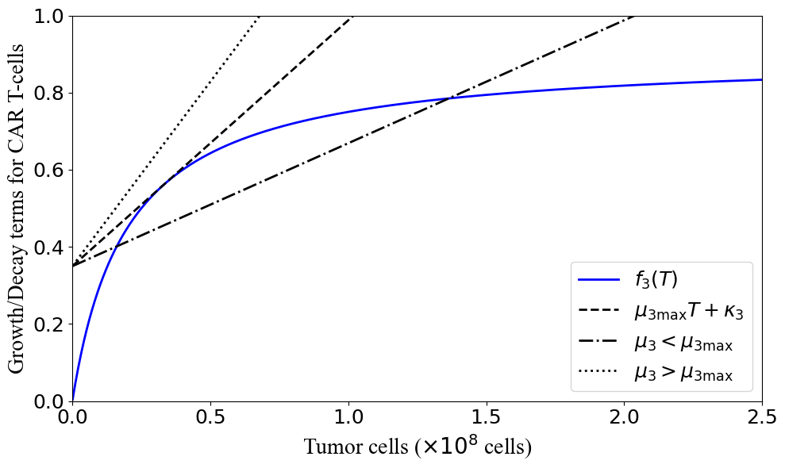

```python
import matplotlib.pyplot as plt
import numpy as np

K_3 = 2 * 10**7
alpha_3 = 0.9
kappa_3 = 0.35


def f_3(T, alpha_3, K_3):
    return alpha_3 * T / (K_3 + T)


def g_3(T, alpha_3, K_3, kappa_3):
    return (f_3(T, alpha_3, K_3) - kappa_3) / T


def g_3_prime(T, alpha_3, K_3, kappa_3):
    return (1 / (T**2 * (K_3 + T)**2)) * (
        (kappa_3 - alpha_3) * T**2 + 2 * kappa_3 * K_3 * T + kappa_3 * K_3**2
    )


def T_bar(alpha_3, kappa_3, K_3):
    if alpha_3 > kappa_3:
        return (np.sqrt(kappa_3) / (np.sqrt(alpha_3) - np.sqrt(kappa_3))) * K_3
    return None


def mu_3_max(alpha_3, K_3, kappa_3):
    T_0 = T_bar(alpha_3, kappa_3, K_3)
    if T_0 is not None:
        return g_3(T_0, alpha_3, K_3, kappa_3)
    return None


mu_3_max_value = mu_3_max(alpha_3, K_3, kappa_3)
print(mu_3_max_value)

mu_3_lower = mu_3_max_value * 0.5
mu_3_higher = mu_3_max_value * 1.5

T_values = np.linspace(1e5, 5e8, 1000)
f_3_values = f_3(T_values, alpha_3, K_3)
mu_3_line_max = mu_3_max_value * T_values + kappa_3
mu_3_line_lower = mu_3_lower * T_values + kappa_3
mu_3_line_higher = mu_3_higher * T_values + kappa_3

plt.figure(figsize=(10, 6))

plt.plot(T_values, f_3_values, label=r'$f_3(T)$', color='b', linestyle='-', linewidth=2)
plt.plot(T_values, mu_3_line_max, label=r'$\mu_{3\max} T + \kappa_3$', color='black', linestyle='--', linewidth=2)
plt.plot(T_values, mu_3_line_lower, label=r'$\mu_3 < \mu_{3\max}$', color='black', linestyle='-.', linewidth=2)
plt.plot(T_values, mu_3_line_higher, label=r'$\mu_3 > \mu_{3\max}$', color='black', linestyle=':', linewidth=2)

plt.xlabel(r"Tumor cells ($\times10^8$ cells)", fontname="Times New Roman", fontsize=20)
plt.ylabel("Growth/Decay terms for CAR T-cells", fontname="Times New Roman", fontsize=20)
plt.legend(fontsize=18)

ax = plt.gca()
ax.xaxis.offsetText.set_visible(False)

plt.xlim(0, 2.5e8)
plt.ylim(0, 1)
plt.xticks(fontsize=18)
plt.yticks(fontsize=18)
plt.tight_layout()

plt.savefig('./figures/fig2.pdf')
```

# Oscillating solutions and Hopf bifurcation

The existence of oscilations of $E^*$ depends on $$ \tilde{\Delta}(T^*)=T^{*3}+2K_3T^{*2}+\left(K_3+4\dfrac{\alpha_3}{\alpha_1}K_1\right)K_3T^{*}-4\dfrac{\alpha_3}{\alpha_1}K_1^2K_{3}, $$ where $\dfrac{\kappa_2}{\alpha_2}<T^*<K_1$.

There exists a unique $\tilde{T}^* \in \left(0, K_1\right)$ such that $\tilde{\Delta}(\tilde{T}^*) = 0$.

$$ \alpha_1 \geq \tilde{\alpha}_1:=\dfrac{4\alpha_2^2\alpha_3K_1K_3(\alpha_2K_1-\kappa_2)}{\kappa_2(\alpha_2K_3+\kappa_2)^2} $$

Then, the unique T value is identified as $\tilde{T}^*=3.86\cdot10^8$ cells, and $\tilde{\alpha}_1=3,85\cdot 10^4$.

We need to check the position of $\tilde{T}^*$ with respect to $\dfrac{\kappa_2}{\alpha_2}$. This is given by the sign of $$\tilde{\Delta}\left(\dfrac{\kappa_2}{\alpha_2}\right)=\dfrac{\kappa_2^3}{\alpha_2^3}+2K_3\dfrac{\kappa_2^2}{\alpha_2^2}+K_3^2\dfrac{\kappa_2}{\alpha_2}-4K_1K_3\dfrac{\alpha_3}{\alpha_1}\left(K_1-\dfrac{\kappa_2}{\alpha_2}\right).$$ Then, $$\tilde{\Delta}\left(\dfrac{\kappa_2}{\alpha_2}\right) \geq 0$$ if, and only if, $$\alpha_1 \geq \tilde{\alpha}_1:=\dfrac{4\alpha_2^2\alpha_3K_1K_3(\alpha_2K_1-\kappa_2)}{\kappa_2(\alpha_2K_3+\kappa_2)^2}$$

We conclude that, if $\alpha_1\geq \tilde{\alpha}_1$, then $\tilde{\Delta}(T^*) \geq 0$, for all $\dfrac{\kappa_2}{\alpha_2}<T^*<K_1$. So, the equilibrium $E^*$ is a locally asymptotically stable sink. Suppose now that

$$ \alpha_1<\tilde{\alpha}_1:=\dfrac{4\alpha_2^2\alpha_3K_1K_3(\alpha_2K_1-\kappa_2)}{\kappa_2(\alpha_2K_3+\kappa_2)^2}.$$

We have $\tilde{T}^* \in \left(\dfrac{\kappa_2}{\alpha_2}, K_1\right)$. So, if $T^* \in \left(\dfrac{\kappa_2}{\alpha_2},\tilde{T}^*\right)$, then the equilibrium $E^*$ is a locally asymptotically stable spiral, and if $T^* \in \left(\tilde{T}^*,K_1\right)$, it is a locally asymptotically stable sink.

```
alpha1 = 0.69  <  alpha1tilde = 3.854275e+04
Ttilde = 3.867590e+08
```

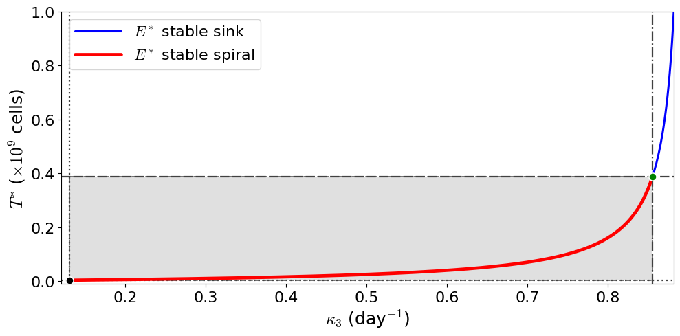

```python
import matplotlib.pyplot as plt
import numpy as np
import sympy as sm
from matplotlib.patches import Rectangle

alpha1 = 0.69
K1 = 10**9
mu1 = 10**-7

alpha2 = 10**-7
K2 = 10**9
kappa2 = 0.34

K3 = 2 * 10**7
alpha3 = 0.9

T = sm.Symbol('T', real=True)
delta_tilde_t = (
    T**3
    + 2 * K3 * T**2
    + (K3 + 4 * K1 * (alpha3 / alpha1)) * K3 * T
    - 4 * K3 * K1**2 * (alpha3 / alpha1)
)

roots = sm.nroots(delta_tilde_t)
Ttilde_value = float([r for r in roots if abs(sm.im(r)) < 1e-10 and sm.re(r) > 0][0])

alpha1tilde_value = (
    4 * (alpha2**2) * alpha3 * K1 * K3 * (alpha2 * K1 - kappa2)
) / (kappa2 * (alpha2 * K3 + kappa2) ** 2)

print(f"alpha1 = {alpha1}  <  alpha1tilde = {alpha1tilde_value:.6e}")
print(f"Ttilde = {Ttilde_value:.6e}")

liminf = alpha3 * kappa2 / (kappa2 + alpha2 * K3)
limsup = alpha3 * K1 / (K1 + K3)
kappa3_list = np.linspace(liminf, limsup, 900)

Tcoex = (kappa3_list * K3) / (alpha3 - kappa3_list)
T_lower = kappa2 / alpha2
kappa3_tilde = alpha3 * Ttilde_value / (K3 + Ttilde_value)

mask_spiral = (Tcoex > T_lower) & (Tcoex < Ttilde_value)
mask_sink = (Tcoex >= Ttilde_value) & (Tcoex <= K1)

plt.rcParams['mathtext.fontset'] = 'cm'

fig, ax = plt.subplots()
fig.set_size_inches(10, 5)

window = Rectangle(
    (liminf, T_lower),
    width=(kappa3_tilde - liminf),
    height=(Ttilde_value - T_lower),
    facecolor='0.88',
    edgecolor='0.35',
    linewidth=1.2,
    linestyle=(0, (4, 2)),
    zorder=0
)
ax.add_patch(window)

ax.plot(
    kappa3_list[mask_sink],
    Tcoex[mask_sink],
    color='blue',
    lw=2.2,
    solid_capstyle='round',
    label=r"$E^*$ stable sink",
    zorder=3
)

ax.plot(
    kappa3_list[mask_spiral],
    Tcoex[mask_spiral],
    color='red',
    lw=3.4,
    solid_capstyle='round',
    label=r"$E^*$ stable spiral",
    zorder=4
)

ax.axhline(Ttilde_value, color='0.25', lw=1.6, linestyle=(0, (6, 2)), zorder=2)
ax.axhline(T_lower, color='0.25', lw=1.6, linestyle=(0, (1, 2)), zorder=2)
ax.axvline(kappa3_tilde, color='0.25', lw=1.6, linestyle='-.', zorder=2)
ax.axvline(liminf, color='0.25', lw=1.6, linestyle=':', zorder=2)

ax.plot(
    [liminf], [T_lower],
    marker='o', linestyle='None', ms=8,
    mfc='k', mec='white', mew=1.1, zorder=8
)

ax.plot(
    [kappa3_tilde], [Ttilde_value],
    marker='o', linestyle='None', ms=8,
    mfc='green', mec='white', mew=1.1, zorder=8
)

ax.set_xlim(liminf - 0.01, limsup)
ax.set_ylim(-1e7, K1)

ax.set_xlabel(r'$\kappa_{3}$ (day$^{-1}$)', fontsize=18)
ax.set_ylabel(r'$T^{*}$ ($\times 10^9$ cells)', fontsize=18)
ax.tick_params(axis='both', labelsize=16)
ax.yaxis.offsetText.set_visible(False)

ax.legend(fontsize=16, loc=2, frameon=True, handlelength=3)

fig.tight_layout()
fig.savefig('./figures/fig5.pdf', bbox_inches='tight', dpi=300)
```

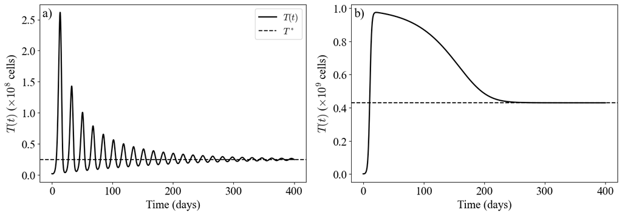

```python
import numpy as np
import matplotlib.pyplot as plt
from scipy.integrate import odeint
from matplotlib.ticker import ScalarFormatter

alpha1 = 0.69
K1 = 1e9
mu1 = 1e-7
beta1 = 0

alpha2 = 1e-7
K2 = 1e9
kappa2 = 0.34

K3 = 2e7
alpha3 = 0.9

plt.rcParams.update({
    "font.size": 14,
    "xtick.labelsize": 12,
    "ytick.labelsize": 12,
    "font.family": "serif",
    "font.serif": ["Times New Roman"],
    "mathtext.fontset": "cm",
})


class ScalarFormatter1Dec(ScalarFormatter):
    def _set_format(self):
        self.format = '%.1f'


def sis(TMC, t, kappa3, beta1):
    T, M, C = TMC
    dT = alpha1 * T * (1 - (T / K1)) * (1 + (beta1 * M)) - mu1 * T * C
    dM = alpha2 * T * M * (1 - (M / K2)) - kappa2 * M
    dC = (alpha3 * T * C) / (K3 + T) - kappa3 * C
    return dT, dM, dC


def T_star_from_kappa3(kappa3):
    return kappa3 * K3 / (alpha3 - kappa3)


TMC0 = [2e6, 1e6, 1e7]
t = np.linspace(0, 400, 100000)

kappa3_cases = [0.5, 0.86]
panel_labels = ['a)', 'b)']

fig, axes = plt.subplots(1, 2, figsize=(14, 5), sharex=True, sharey=False)

for ax, k3, lab in zip(axes, kappa3_cases, panel_labels):
    sim = odeint(sis, TMC0, t, args=(k3, beta1))
    T_sim = sim[:, 0]
    T_star = T_star_from_kappa3(k3)

    ax.plot(t, T_sim, 'k-', lw=2)
    ax.axhline(T_star, color='k', linestyle='--', lw=1.6)

    ax.text(0.01, 0.98, lab, transform=ax.transAxes, fontsize=20, va='top')

    fmt_y = ScalarFormatter1Dec(useMathText=True)
    fmt_y.set_scientific(True)
    fmt_y.set_useOffset(True)
    fmt_y.set_powerlimits((0, 0))
    ax.yaxis.set_major_formatter(fmt_y)
    ax.ticklabel_format(axis='y', style='sci', scilimits=(0, 0), useMathText=True)
    ax.yaxis.offsetText.set_visible(False)

    ax.xaxis.offsetText.set_visible(False)
    ax.tick_params(labelsize=18)
    ax.set_xlabel('Time (days)', fontsize=18)

axes[0].set_ylabel(r'$T(t)$ ($\times10^8$ cells)', fontsize=18)
axes[1].set_ylabel(r'$T(t)$ ($\times10^9$ cells)', fontsize=18)

axes[0].plot([], [], 'k-', lw=2.0, label=r'$T(t)$')
axes[0].plot([], [], 'k--', lw=1.6, label=r'$T^*$')
axes[0].legend(fontsize=14, frameon=True, loc='best')

plt.tight_layout()
plt.savefig('./figures/fig6.pdf', bbox_inches='tight', dpi=300)
```

```
beta1* ≈ 5.905605009617e-11
Bracket used: [5.905539055391e-11, 5.905769057691e-11]  (width=2.300e-15)
Residual |Q(beta1*)| ≈ 4.163336e-16
[Robustness] npts=500000: beta1* ≈ 5.905583811168e-11 | Δ≈2.120e-16 | |Q|≈3.228e-08
[Robustness] npts=500000: beta1* ≈ 5.905583811168e-11 | Δ≈2.120e-16 | |Q|≈3.228e-08
```

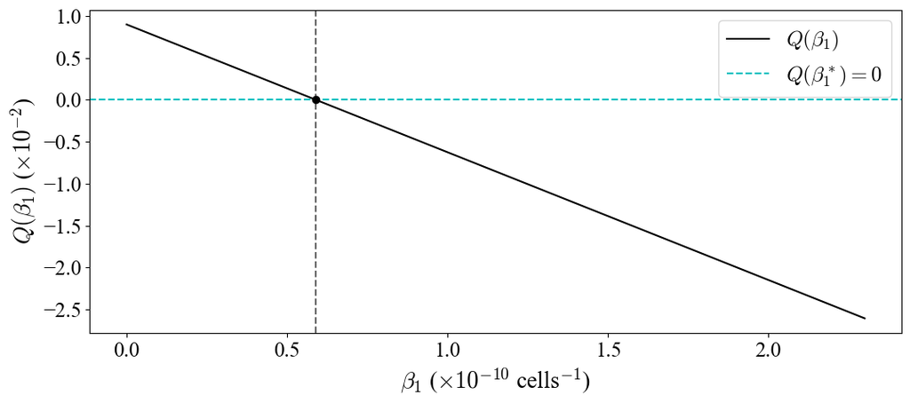

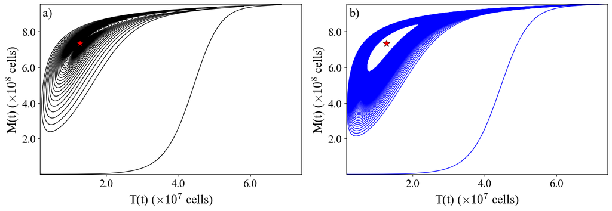

```python
import numpy as np
import matplotlib.pyplot as plt
from scipy.optimize import brentq
from scipy.integrate import odeint
from matplotlib.ticker import ScalarFormatter

alpha1 = 0.69
K1 = 1e9
mu1 = 1e-7

alpha2 = 1e-7
K2 = 1e9
kappa2 = 0.34

K3 = 2e7
alpha3 = 0.9
kappa3 = 0.35

Tcoex = (kappa3 * K3) / (alpha3 - kappa3)
Mcoex = K2 * (1.0 - kappa2 / (alpha2 * Tcoex))


def Q(beta1):
    Ccoex = (alpha1 / mu1) * (1.0 - Tcoex / K1) * (1.0 + beta1 * Mcoex)

    a11 = -(alpha1 / K1) * Tcoex * (1.0 + beta1 * Mcoex)
    a12 = alpha1 * Tcoex * (1.0 - Tcoex / K1) * beta1
    a13 = -mu1 * Tcoex

    a21 = alpha2 * Mcoex * (1.0 - Mcoex / K2)
    a22 = -kappa2 + alpha2 * Tcoex * (1.0 - (2.0 * Mcoex / K2))

    a31 = (alpha3 * Ccoex * K3) / (K3 + Tcoex) ** 2

    q1 = -(a11 + a22)
    q2 = a11 * a22 - a12 * a21 - a13 * a31
    q3 = a13 * a22 * a31

    return q1 * q2 - q3


beta1_min = 0.0
beta1_max = 2.3e-10
npts = 100000

beta1_list = np.linspace(beta1_min, beta1_max, npts)
Qvals = np.array([Q(b) for b in beta1_list])

sgn = np.sign(Qvals)
idx = np.where(sgn[:-1] * sgn[1:] < 0)[0]

if len(idx) == 0:
    raise RuntimeError("No sign change detected in Q(beta1) over the selected interval.")

i = idx[0]
a_br, b_br = beta1_list[i], beta1_list[i + 1]

beta1_star = brentq(Q, a_br, b_br, xtol=1e-15, rtol=1e-12, maxiter=500)

print(f"beta1* ≈ {beta1_star:.12e}")
print(f"Bracket used: [{a_br:.12e}, {b_br:.12e}]  (width={b_br - a_br:.3e})")
print(f"Residual |Q(beta1*)| ≈ {abs(Q(beta1_star)):.6e}")

for npts_test in [500000, 500000]:
    beta1_list_test = np.linspace(beta1_min, beta1_max, npts_test)
    Qvals_test = np.array([Q(x) for x in beta1_list_test])
    sgn_test = np.sign(Qvals_test)
    idx_test = np.where(sgn_test[:-1] * sgn_test[1:] < 0)[0]

    if len(idx_test) == 0:
        print(f"[Robustness] npts={npts_test}: no sign change found.")
        continue

    j = idx_test[0]
    a2, b2 = beta1_list_test[j], beta1_list_test[j + 1]
    beta_star_test = brentq(Q, a2, b2, xtol=1e-15, rtol=1e-12, maxiter=500)

    print(
        f"[Robustness] npts={npts_test}: beta1* ≈ {beta_star_test:.12e} | "
        f"Δ≈{abs(beta_star_test - beta1_star):.3e} | "
        f"|Q|≈{abs(Q(beta_star_test)):.3e}"
    )

plt.figure()
plt.plot(beta1_list, Qvals, '-k', label=r'$Q(\beta_1)$')
plt.axhline(0.0, color='c', linestyle='--', label=r'$Q(\beta_1^*)=0$')
plt.axvline(beta1_star, color='0.4', linestyle='--', lw=1.5)
plt.plot([beta1_star], [0.0], marker='o', ms=6, color='k')

plt.ticklabel_format(style='sci', axis='both', scilimits=(0, 0))
plt.xlabel(r'$\beta_1$ ($\times10^{-10}$ cells$^{-1}$)', fontname="Times New Roman", fontsize=20)
plt.ylabel(r'$Q(\beta_1)$ ($\times10^{-2}$)', fontname="Times New Roman", fontsize=20)

plt.gca().xaxis.offsetText.set_visible(False)
plt.gca().yaxis.offsetText.set_visible(False)

plt.xticks(fontsize=18)
plt.yticks(fontsize=18)
plt.legend(fontsize=18)

plt.gcf().set_size_inches(11, 5)
plt.tight_layout()
plt.savefig('./figures/fig7.pdf', bbox_inches='tight', dpi=300)
plt.show()


def sis(TMC, t, beta1):
    T, M, C = TMC
    dT = alpha1 * T * (1.0 - (T / K1)) * (1.0 + beta1 * M) - mu1 * T * C
    dM = alpha2 * T * M * (1.0 - (M / K2)) - kappa2 * M
    dC = (alpha3 * T * C) / (K3 + T) - kappa3 * C
    return dT, dM, dC


TMC0 = [2e6, 1e6, 1e7]
t_end = 8000.0
N_t = 120000
t = np.linspace(0, t_end, N_t)

RTOL = 1e-10
ATOL = 1e-12
MXSTEP = 5000


def simulate_TM(beta1):
    sol = odeint(sis, TMC0, t, args=(beta1,), rtol=RTOL, atol=ATOL, mxstep=MXSTEP)
    return sol[:, 0], sol[:, 1]


beta_a = 0.0
eps = 0.05
beta_b = beta1_star * (1.0 + eps)

Ta, Ma = simulate_TM(beta_a)
Tb, Mb = simulate_TM(beta_b)


class ScalarFormatter1Dec(ScalarFormatter):
    def _set_format(self):
        self.format = '%.1f'


def apply_sci_1dec_with_power(ax, axis='both'):
    if axis in ('both', 'x'):
        fmtx = ScalarFormatter1Dec(useMathText=True)
        fmtx.set_scientific(True)
        fmtx.set_useOffset(True)
        fmtx.set_powerlimits((0, 0))
        ax.xaxis.set_major_formatter(fmtx)
        ax.ticklabel_format(axis='x', style='sci', scilimits=(0, 0), useMathText=True)
        ax.xaxis.offsetText.set_visible(False)

    if axis in ('both', 'y'):
        fmty = ScalarFormatter1Dec(useMathText=True)
        fmty.set_scientific(True)
        fmty.set_useOffset(True)
        fmty.set_powerlimits((0, 0))
        ax.yaxis.set_major_formatter(fmty)
        ax.ticklabel_format(axis='y', style='sci', scilimits=(0, 0), useMathText=True)
        ax.yaxis.offsetText.set_visible(False)


xmin = min(Ta.min(), Tb.min())
xmax = max(Ta.max(), Tb.max())
ymin = min(Ma.min(), Mb.min())
ymax = max(Ma.max(), Mb.max())

lw_traj = 1.0

fig, axes = plt.subplots(1, 2, figsize=(14, 5), sharex=False, sharey=False)

axes[0].plot(Ta, Ma, color='k', linewidth=lw_traj, zorder=2)
axes[0].plot(
    Tcoex, Mcoex,
    marker='*', color='red', markersize=12,
    markeredgecolor='k', markeredgewidth=0.6, zorder=3
)
axes[0].set_xlabel(r'T(t) ($\times 10^7$ cells)', fontname="Times New Roman", fontsize=20)
axes[0].set_ylabel(r'M(t) ($\times 10^8$ cells)', fontname="Times New Roman", fontsize=20)
axes[0].text(0.01, 0.98, 'a)', transform=axes[0].transAxes, fontsize=20, va='top')
axes[0].tick_params(labelsize=18)
apply_sci_1dec_with_power(axes[0], axis='both')
axes[0].set_xlim(xmin, xmax)
axes[0].set_ylim(ymin, ymax)

axes[1].plot(Tb, Mb, color='blue', linewidth=lw_traj, zorder=2)
axes[1].plot(
    Tcoex, Mcoex,
    marker='*', color='red', markersize=12,
    markeredgecolor='k', markeredgewidth=0.6, zorder=3
)
axes[1].set_xlabel(r'T(t) ($\times 10^7$ cells)', fontname="Times New Roman", fontsize=20)
axes[1].set_ylabel(r'M(t) ($\times 10^8$ cells)', fontname="Times New Roman", fontsize=20)
axes[1].text(0.01, 0.98, 'b)', transform=axes[1].transAxes, fontsize=20, va='top')
axes[1].tick_params(labelsize=18)
apply_sci_1dec_with_power(axes[1], axis='both')
axes[1].set_xlim(xmin, xmax)
axes[1].set_ylim(ymin, ymax)

fig.tight_layout()
fig.savefig('./figures/fig8.pdf', bbox_inches='tight', dpi=300)
plt.show()
```

# Parameter stability space

```
alpha2_min  = 3.400e-10
alpha3_min  = 0.357000
```

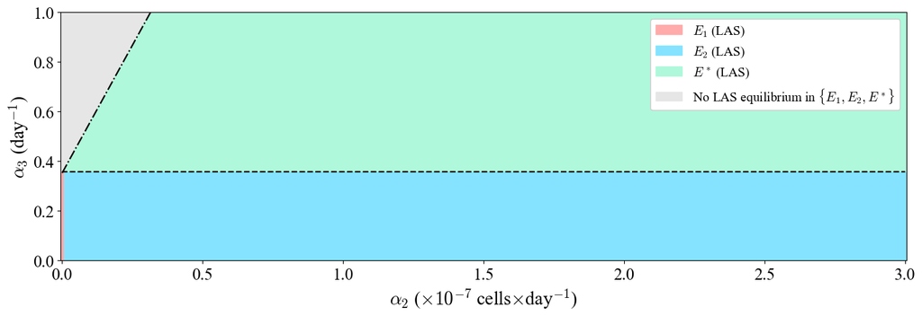

```python
import numpy as np
import matplotlib.pyplot as plt
from matplotlib.colors import ListedColormap, BoundaryNorm
import matplotlib.patches as mpatches
from matplotlib.lines import Line2D

K1 = 1e9
K2 = 1e9
K3 = 2e7

alpha1 = 0.69
alpha2_ref = 1e-7
alpha3_ref = 0.9

mu1 = 1e-7
kappa2 = 0.34
kappa3 = 0.35

mu3 = 0.0
beta1 = 0.0

alpha2_min = kappa2 / K1
alpha3_min = kappa3 * (1.0 + K3 / K1)


def alpha3_max(alpha2):
    return kappa3 * (1.0 + (alpha2 / kappa2) * K3)


print(f"alpha2_min  = {alpha2_min:.3e}")
print(f"alpha3_min  = {alpha3_min:.6f}")

n_a2 = 300
n_a3 = 300

alpha2_vals = np.linspace(1e-10, 3e-7, n_a2)
alpha3_vals = np.linspace(0.0, 1.0, n_a3)

A2, A3 = np.meshgrid(alpha2_vals, alpha3_vals)

stab_code = np.zeros_like(A2, dtype=int)

for i in range(n_a3):
    for j in range(n_a2):
        a2 = A2[i, j]
        a3 = A3[i, j]
        a3_max_ij = alpha3_max(a2)

        if a3 < alpha3_min:
            if a2 < alpha2_min:
                stab_code[i, j] = 1
            elif a2 > alpha2_min:
                stab_code[i, j] = 2
            else:
                stab_code[i, j] = 0
        elif (a3 > alpha3_min) and (a3 < a3_max_ij):
            stab_code[i, j] = 3
        else:
            stab_code[i, j] = 0

plt.rcParams.update({
    'font.size': 16,
    'xtick.labelsize': 16,
    'ytick.labelsize': 16,
    'font.family': 'serif',
    'font.serif': ['Times New Roman']
})

fig, ax = plt.subplots(figsize=(14, 5))

COL_NONE = '#E6E6E6'
COL_E1 = '#FFABAB'
COL_E2 = '#85E3FF'
COL_Es = '#AFF8DB'

cmap = ListedColormap([COL_NONE, COL_E1, COL_E2, COL_Es])
bounds = [-0.5, 0.5, 1.5, 2.5, 3.5]
norm = BoundaryNorm(bounds, cmap.N)

ax.pcolormesh(A2, A3, stab_code, cmap=cmap, norm=norm, shading='auto')

ax.plot(
    alpha2_vals,
    np.full_like(alpha2_vals, alpha3_min),
    color='k',
    linestyle='--',
    linewidth=1.6
)
ax.plot(
    alpha2_vals,
    alpha3_max(alpha2_vals),
    color='k',
    linestyle='-.',
    linewidth=1.6
)

ax.set_xlabel(r'$\alpha_2$ ($\times 10^{-7}$ cells$\times$day$^{-1}$)', fontsize=20)
ax.set_ylabel(r'$\alpha_3$ (day$^{-1}$)', fontsize=20)
ax.set_ylim(alpha3_vals.min(), alpha3_vals.max())
ax.tick_params(axis='both', labelsize=18)
ax.xaxis.offsetText.set_visible(False)

patch_E1 = mpatches.Patch(color=COL_E1, label=r'$E_1$ (LAS)')
patch_E2 = mpatches.Patch(color=COL_E2, label=r'$E_2$ (LAS)')
patch_Es = mpatches.Patch(color=COL_Es, label=r'$E^*$ (LAS)')
patch_none = mpatches.Patch(color=COL_NONE, label=r'No LAS equilibrium in $\{E_1,E_2,E^*\}$')

h_min = Line2D([0], [0], color='k', linestyle='--', linewidth=1.6, label=r'$\alpha_{3\min}$')
h_max = Line2D([0], [0], color='k', linestyle='-.', linewidth=1.6, label=r'$\alpha_{3\max}(\alpha_2)$')

ax.legend(
    handles=[patch_E1, patch_E2, patch_Es, patch_none],
    loc='upper right',
    fontsize=14,
    frameon=True,
    framealpha=1.0
)

plt.tight_layout()
plt.savefig('./figures/stability_space1.png', dpi=300, bbox_inches='tight')
plt.show()
```

```
bar K1 ≈ 1.818e+07  (K1_case1 = 2.000e+07)
```

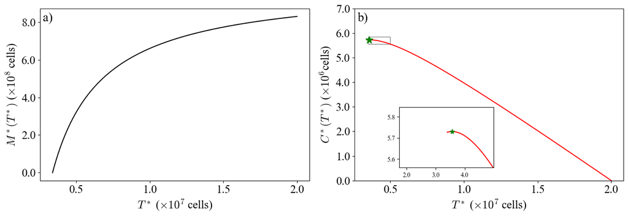

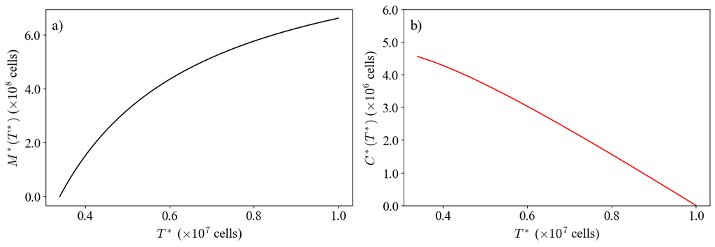

```python
import numpy as np
import matplotlib.pyplot as plt
from matplotlib.ticker import ScalarFormatter
from mpl_toolkits.axes_grid1.inset_locator import inset_axes
import matplotlib.patches as patches

alpha1 = 0.69
mu1 = 1e-7
alpha2 = 1e-7
kappa2 = 0.34
K2 = 1e9
beta1 = 2.3e-10


def M_star(T_star, alpha2, K2, kappa2):
    return K2 * (1.0 - kappa2 / (alpha2 * T_star))


def C_star(T_star, alpha1, mu1, beta1, K1, alpha2, K2, kappa2):
    Mst = M_star(T_star, alpha2, K2, kappa2)
    return (alpha1 / mu1) * (1.0 - T_star / K1) * (1.0 + beta1 * Mst)


def bar_K1(alpha2, beta1, K2, kappa2):
    return kappa2 * (1.0 + beta1 * K2) / (alpha2 * beta1 * K2)


def bar_T_star(K1, alpha2, beta1, K2, kappa2):
    num = beta1 * K1 * K2 * kappa2
    den = alpha2 * (1.0 + beta1 * K2)
    return np.sqrt(num / den)


K1_case1 = 2.0e7

barK1_val = bar_K1(alpha2, beta1, K2, kappa2)
print(f"bar K1 ≈ {barK1_val:.3e}  (K1_case1 = {K1_case1:.3e})")

T_min = kappa2 / alpha2
T_max_case1 = K1_case1
T_values_case1 = np.linspace(T_min, T_max_case1, 400)

M_case1 = M_star(T_values_case1, alpha2, K2, kappa2)
C_case1 = C_star(T_values_case1, alpha1, mu1, beta1, K1_case1, alpha2, K2, kappa2)
T_bar_case1 = bar_T_star(K1_case1, alpha2, beta1, K2, kappa2)

K1_case2 = 1.0e7

T_max_case2 = K1_case2
T_values_case2 = np.linspace(T_min, T_max_case2, 400)

M_case2 = M_star(T_values_case2, alpha2, K2, kappa2)
C_case2 = C_star(T_values_case2, alpha1, mu1, beta1, K1_case2, alpha2, K2, kappa2)
T_bar_case2 = bar_T_star(K1_case2, alpha2, beta1, K2, kappa2)

plt.rcParams.update({
    "font.size": 14,
    "xtick.labelsize": 12,
    "ytick.labelsize": 12,
    "font.family": "serif",
    "font.serif": ["Times New Roman"]
})


class ScalarFormatterWithDecimals(ScalarFormatter):
    def _set_format(self):
        self.format = '%.1f'


fig3, axes3 = plt.subplots(1, 2, figsize=(14, 5))

for ax in axes3:
    ax.yaxis.offsetText.set_visible(False)
    ax.xaxis.offsetText.set_visible(False)

axes3[0].plot(T_values_case1, M_case1, 'k-')
axes3[0].set_xlabel(r'$T^*$ ($\times10^{7}$ cells)', fontsize=18)
axes3[0].set_ylabel(r'$M^*(T^*)$ ($\times10^{8}$ cells)', fontsize=18)
axes3[0].tick_params(labelsize=18)
axes3[0].text(0.01, 0.98, 'a)', transform=axes3[0].transAxes, fontsize=20, va='top')
axes3[0].xaxis.set_major_formatter(ScalarFormatterWithDecimals())
axes3[0].yaxis.set_major_formatter(ScalarFormatterWithDecimals())

axes3[1].plot(T_values_case1, C_case1, 'r-')

if T_min < T_bar_case1 < T_max_case1:
    C_bar_case1 = C_star(
        T_bar_case1, alpha1, mu1, beta1,
        K1_case1, alpha2, K2, kappa2
    )
    axes3[1].plot(T_bar_case1, C_bar_case1, marker='*', color='green', markersize=12)

axes3[1].set_xlabel(r'$T^*$ ($\times10^{7}$ cells)', fontsize=18)
axes3[1].set_ylabel(r'$C^*(T^*)$ ($\times10^{6}$cells)', fontsize=18)
axes3[1].set_ylim(0, 7e6)
axes3[1].text(0.01, 0.98, 'b)', transform=axes3[1].transAxes, fontsize=20, va='top')
axes3[1].xaxis.set_major_formatter(ScalarFormatterWithDecimals())
axes3[1].yaxis.set_major_formatter(ScalarFormatterWithDecimals())
axes3[1].tick_params(labelsize=18)

factor_left = 0.98
factor_right = 1.4

T_zoom_min = T_bar_case1 * factor_left
T_zoom_max = T_bar_case1 * factor_right

mask_zoom = (T_values_case1 >= T_zoom_min) & (T_values_case1 <= T_zoom_max)
T_zoom = T_values_case1[mask_zoom]
C_zoom = C_case1[mask_zoom]

axins = inset_axes(
    axes3[1],
    width="35%",
    height="35%",
    loc="lower left",
    bbox_to_anchor=(0.15, 0.05, 1, 1),
    bbox_transform=axes3[1].transAxes,
    borderpad=0.5
)

axins.plot(T_values_case1, C_case1, 'r-')
axins.plot(T_bar_case1, C_bar_case1, marker='*', color='green', markersize=8)

axins.set_xlim(T_zoom_min * 0.5, T_zoom_max)
axins.set_ylim(C_zoom.min(), C_zoom.max() * 1.02)

axins.xaxis.set_major_formatter(ScalarFormatterWithDecimals())
axins.yaxis.set_major_formatter(ScalarFormatterWithDecimals())
axins.yaxis.offsetText.set_visible(False)
axins.xaxis.offsetText.set_visible(False)
axins.tick_params(labelsize=10)

rect = patches.Rectangle(
    (T_zoom_min, C_zoom.min()),
    T_zoom_max - T_zoom_min,
    C_zoom.max() * 1.02 - C_zoom.min(),
    linewidth=1,
    edgecolor='0.5',
    facecolor='none'
)
axes3[1].add_patch(rect)

plt.tight_layout()
plt.savefig('./figures/fig3.pdf', bbox_inches='tight')
plt.show()

fig4, axes4 = plt.subplots(1, 2, figsize=(14, 5))

for ax in axes4:
    ax.yaxis.offsetText.set_visible(False)
    ax.xaxis.offsetText.set_visible(False)

axes4[0].plot(T_values_case2, M_case2, 'k-')
axes4[0].set_xlabel(r'$T^*$ ($\times10^{7}$ cells)', fontsize=18)
axes4[0].set_ylabel(r'$M^*(T^*)$ ($\times10^{8}$ cells)', fontsize=18)
axes4[0].tick_params(labelsize=18)
axes4[0].text(0.02, 0.95, 'a)', transform=axes4[0].transAxes, fontsize=20, va='top')
axes4[0].xaxis.set_major_formatter(ScalarFormatterWithDecimals())
axes4[0].yaxis.set_major_formatter(ScalarFormatterWithDecimals())

axes4[1].plot(T_values_case2, C_case2, 'r-')
axes4[1].set_xlabel(r'$T^*$ ($\times10^{7}$ cells)', fontsize=18)
axes4[1].set_ylabel(r'$C^*(T^*)$ ($\times10^{6}$ cells)', fontsize=18)
axes4[1].tick_params(labelsize=18)
axes4[1].set_ylim(0, 6e6)
axes4[1].text(0.02, 0.95, 'b)', transform=axes4[1].transAxes, fontsize=20, va='top')
axes4[1].xaxis.set_major_formatter(ScalarFormatterWithDecimals())
axes4[1].yaxis.set_major_formatter(ScalarFormatterWithDecimals())

plt.tight_layout()
plt.savefig('./figures/fig4.pdf', bbox_inches='tight')
plt.show()
```

# Global Sensitivity Analisys

```python
from scipy import integrate as sp
import numpy as np
from SALib.sample import fast_sampler
from SALib.analyze import fast
import pandas as pd
import matplotlib.pyplot as plt


def sis(TMC, t, alpha1, alpha2, alpha3, beta1, K1, K2, K3, mu1, kappa2, kappa3):
    T, M, C = TMC
    dT = alpha1 * T * (1 - (T / K1)) * (1 + (beta1 * M)) - mu1 * T * C
    dM = alpha2 * T * M * (1 - (M / K2)) - kappa2 * M
    dC = (alpha3 * T * C) / (K3 + T) - kappa3 * C
    return dT, dM, dC


alpha1 = 0.69
K1 = 10**9
beta1 = 5.9e-11
mu1 = 1e-7

alpha2 = 1e-7
K2 = 10**9
kappa2 = 0.34

alpha3 = 0.9
K3 = 2e7
kappa3 = 0.35

TMC0 = [2e6, 1e6, 1e7]

t = np.linspace(0, 60, 1000)
n_t = len(t)

param_names = [
    'alpha1', 'alpha2', 'alpha3',
    'beta1', 'K1', 'K2', 'K3',
    'mu1', 'kappa2', 'kappa3'
]

base_values = np.array([
    alpha1, alpha2, alpha3,
    beta1, K1, K2, K3,
    mu1, kappa2, kappa3
])

bounds = np.column_stack((0.8 * base_values, 1.2 * base_values))

problem = {
    'num_vars': len(param_names),
    'names': param_names,
    'bounds': bounds
}

N = 10000
M_fast = 4
seed = 123

X = fast_sampler.sample(problem, N, M=M_fast, seed=seed)
n_samples = X.shape[0]

print(f"Number of generated samples: {n_samples}")

Y_full = np.zeros((n_samples, n_t, 3))

for i, pars in enumerate(X):
    sol = sp.odeint(
        sis,
        TMC0,
        t,
        args=tuple(pars)
    )
    Y_full[i, :, :] = sol

np.savez_compressed(
    './sensitivity_results/fast_model_outputs_TMC.npz',
    X=X,
    t=t,
    Y_full=Y_full,
    param_names=np.array(param_names)
)

print("File 'fast_model_outputs_TMC.npz' saved.")

Y_end = Y_full[:, -1, :]

Si_T_end = fast.analyze(
    problem,
    Y_end[:, 0],
    M=M_fast,
    num_resamples=100,
    conf_level=0.95,
    print_to_console=True,
    seed=seed
)

Si_M_end = fast.analyze(
    problem,
    Y_end[:, 1],
    M=M_fast,
    num_resamples=100,
    conf_level=0.95,
    print_to_console=True,
    seed=seed
)

Si_C_end = fast.analyze(
    problem,
    Y_end[:, 2],
    M=M_fast,
    num_resamples=100,
    conf_level=0.95,
    print_to_console=True,
    seed=seed
)

df_T_end = pd.DataFrame({
    'parameter': param_names,
    'S1': Si_T_end['S1'],
    'ST': Si_T_end['ST'],
    'S1_conf': Si_T_end['S1_conf'],
    'ST_conf': Si_T_end['ST_conf']
})
df_T_end.to_csv('./sensitivity_results/fast_Si_T_end.csv', index=False)

df_M_end = pd.DataFrame({
    'parameter': param_names,
    'S1': Si_M_end['S1'],
    'ST': Si_M_end['ST'],
    'S1_conf': Si_M_end['S1_conf'],
    'ST_conf': Si_M_end['ST_conf']
})
df_M_end.to_csv('./sensitivity_results/fast_Si_M_end.csv', index=False)

df_C_end = pd.DataFrame({
    'parameter': param_names,
    'S1': Si_C_end['S1'],
    'ST': Si_C_end['ST'],
    'S1_conf': Si_C_end['S1_conf'],
    'ST_conf': Si_C_end['ST_conf']
})
df_C_end.to_csv('./sensitivity_results/fast_Si_C_end.csv', index=False)

plt.figure(figsize=(8, 4))
plt.bar(param_names, Si_T_end['S1'])
plt.xticks(rotation=45, ha='right')
plt.ylabel('S1 (T, t=60)')
plt.tight_layout()
plt.savefig('./sensitivity_results/fast_S1_T_end_bar.pdf', format='pdf')
plt.close()

print("CSV files and bar plot at the final time were saved.")

time_indices = np.arange(0, n_t, 20)
t_sel = t[time_indices]
n_times_sel = len(t_sel)
n_par = problem['num_vars']

S1_T = np.zeros((n_times_sel, n_par))
ST_T = np.zeros((n_times_sel, n_par))
S1_T_conf = np.zeros((n_times_sel, n_par))
ST_T_conf = np.zeros((n_times_sel, n_par))

S1_M = np.zeros((n_times_sel, n_par))
ST_M = np.zeros((n_times_sel, n_par))
S1_M_conf = np.zeros((n_times_sel, n_par))
ST_M_conf = np.zeros((n_times_sel, n_par))

S1_C = np.zeros((n_times_sel, n_par))
ST_C = np.zeros((n_times_sel, n_par))
S1_C_conf = np.zeros((n_times_sel, n_par))
ST_C_conf = np.zeros((n_times_sel, n_par))

print("Starting time-dependent FAST analysis...")

for k, idx in enumerate(time_indices):
    print(f"  Time t = {t[idx]:.2f} (index {idx})")

    Y_T = Y_full[:, idx, 0]
    Y_M = Y_full[:, idx, 1]
    Y_C = Y_full[:, idx, 2]

    Si_T_t = fast.analyze(
        problem,
        Y_T,
        M=M_fast,
        num_resamples=100,
        conf_level=0.95,
        print_to_console=False,
        seed=seed
    )

    Si_M_t = fast.analyze(
        problem,
        Y_M,
        M=M_fast,
        num_resamples=100,
        conf_level=0.95,
        print_to_console=False,
        seed=seed
    )

    Si_C_t = fast.analyze(
        problem,
        Y_C,
        M=M_fast,
        num_resamples=100,
        conf_level=0.95,
        print_to_console=False,
        seed=seed
    )

    S1_T[k, :] = Si_T_t['S1']
    ST_T[k, :] = Si_T_t['ST']
    S1_T_conf[k, :] = Si_T_t['S1_conf']
    ST_T_conf[k, :] = Si_T_t['ST_conf']

    S1_M[k, :] = Si_M_t['S1']
    ST_M[k, :] = Si_M_t['ST']
    S1_M_conf[k, :] = Si_M_t['S1_conf']
    ST_M_conf[k, :] = Si_M_t['ST_conf']

    S1_C[k, :] = Si_C_t['S1']
    ST_C[k, :] = Si_C_t['ST']
    S1_C_conf[k, :] = Si_C_t['S1_conf']
    ST_C_conf[k, :] = Si_C_t['ST_conf']

np.savez_compressed(
    './sensitivity_results/fast_time_dependent_sensitivity_TMC.npz',
    t_sel=t_sel,
    param_names=np.array(param_names),
    S1_T=S1_T, ST_T=ST_T,
    S1_T_conf=S1_T_conf, ST_T_conf=ST_T_conf,
    S1_M=S1_M, ST_M=ST_M,
    S1_M_conf=S1_M_conf, ST_M_conf=ST_M_conf,
    S1_C=S1_C, ST_C=ST_C,
    S1_C_conf=S1_C_conf, ST_C_conf=ST_C_conf
)

df_S1_T_time = pd.DataFrame(
    np.column_stack([t_sel.reshape(-1, 1), S1_T]),
    columns=['time'] + param_names
)
df_S1_T_time.to_csv('./sensitivity_results/fast_S1_T_time.csv', index=False)

df_S1_M_time = pd.DataFrame(
    np.column_stack([t_sel.reshape(-1, 1), S1_M]),
    columns=['time'] + param_names
)
df_S1_M_time.to_csv('./sensitivity_results/fast_S1_M_time.csv', index=False)

df_S1_C_time = pd.DataFrame(
    np.column_stack([t_sel.reshape(-1, 1), S1_C]),
    columns=['time'] + param_names
)
df_S1_C_time.to_csv('./sensitivity_results/fast_S1_C_time.csv', index=False)

print("Time-dependent FAST analysis completed.")
print("Files '.npz' and '.csv' were saved. You can now use the plotting script.")
```

[output not shown]

[output cut: 34 more lines]

[output not shown]

```python
import numpy as np
import pandas as pd
import matplotlib.pyplot as plt

model_data = np.load('./sensitivity_results/fast_model_outputs_TMC.npz', allow_pickle=True)
t = model_data['t']
Y_full = model_data['Y_full']
param_names = model_data['param_names'].tolist()

sens_data = np.load('./sensitivity_results/fast_time_dependent_sensitivity_TMC.npz', allow_pickle=True)
t_sel = sens_data['t_sel']
S1_T = sens_data['S1_T']
ST_T = sens_data['ST_T']
S1_M = sens_data['S1_M']
ST_M = sens_data['ST_M']
S1_C = sens_data['S1_C']
ST_C = sens_data['ST_C']

df_T_end = pd.read_csv('./sensitivity_results/fast_Si_T_end.csv')
df_M_end = pd.read_csv('./sensitivity_results/fast_Si_M_end.csv')
df_C_end = pd.read_csv('./sensitivity_results/fast_Si_C_end.csv')

print("Data loaded successfully.")
```

[output not shown]

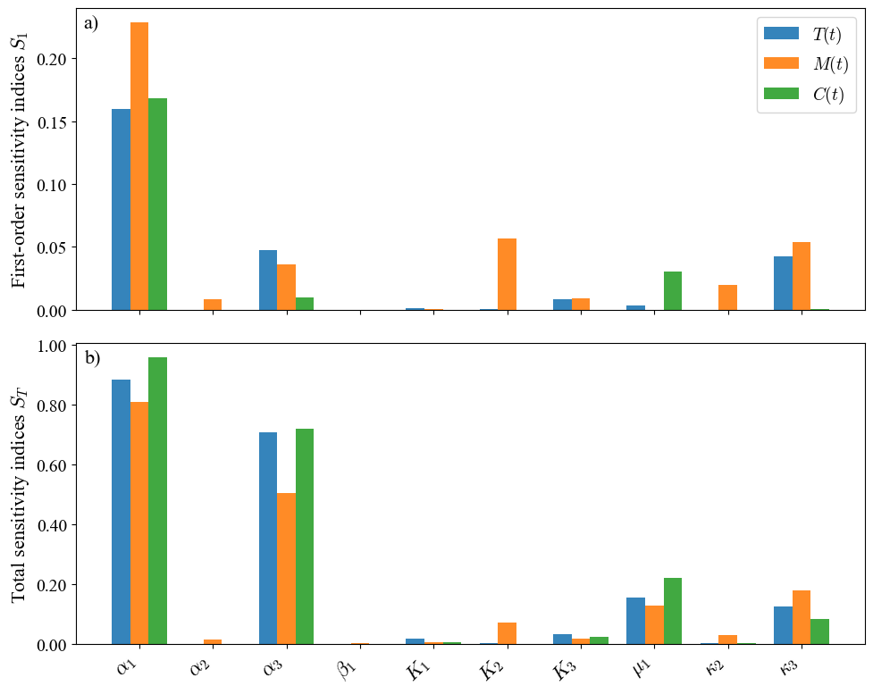

[output not shown]

```python
from matplotlib.ticker import FormatStrFormatter

param_label_map = {
    'alpha1': r'$\alpha_1$',
    'alpha2': r'$\alpha_2$',
    'alpha3': r'$\alpha_3$',
    'beta1': r'$\beta_1$',
    'K1': r'$K_1$',
    'K2': r'$K_2$',
    'K3': r'$K_3$',
    'mu1': r'$\mu_1$',
    'kappa2': r'$\kappa_2$',
    'kappa3': r'$\kappa_3$'
}


def plot_end_bars(df_T_end, df_M_end, df_C_end, filename_prefix):
    params_T = df_T_end['parameter'].values
    params_M = df_M_end['parameter'].values
    params_C = df_C_end['parameter'].values

    if not (np.array_equal(params_T, params_M) and np.array_equal(params_T, params_C)):
        print("Warning: parameter order differs across dataframes. Using the order from T.")

    params = params_T
    x = np.arange(len(params))
    width = 0.25

    S1_T = df_T_end['S1'].values
    S1_M = df_M_end['S1'].values
    S1_C = df_C_end['S1'].values

    ST_T = df_T_end['ST'].values
    ST_M = df_M_end['ST'].values
    ST_C = df_C_end['ST'].values

    xtick_labels = [param_label_map.get(p, p) for p in params]

    fig, axes = plt.subplots(2, 1, figsize=(10, 8), sharex=True)

    ax_top = axes[0]
    ax_top.bar(x - width, S1_T, width, label=r'$T(t)$', alpha=0.9)
    ax_top.bar(x, S1_M, width, label=r'$M(t)$', alpha=0.9)
    ax_top.bar(x + width, S1_C, width, label=r'$C(t)$', alpha=0.9)

    ax_top.set_ylabel(r'First-order sensitivity indices $S_1$', fontsize=16)
    ax_top.tick_params(axis='both', which='major', labelsize=14)
    ax_top.yaxis.set_major_formatter(FormatStrFormatter('%.2f'))
    ax_top.text(0.01, 0.98, 'a)', transform=ax_top.transAxes, fontsize=16, va='top', ha='left')
    ax_top.legend(fontsize=14)

    ax_bottom = axes[1]
    ax_bottom.bar(x - width, ST_T, width, label='T', alpha=0.9)
    ax_bottom.bar(x, ST_M, width, label='M', alpha=0.9)
    ax_bottom.bar(x + width, ST_C, width, label='C', alpha=0.9)

    ax_bottom.set_ylabel(r'Total sensitivity indices $S_T$', fontsize=16)
    ax_bottom.tick_params(axis='both', which='major', labelsize=14)
    ax_bottom.yaxis.set_major_formatter(FormatStrFormatter('%.2f'))
    ax_bottom.text(0.01, 0.98, 'b)', transform=ax_bottom.transAxes, fontsize=16, va='top', ha='left')

    ax_bottom.set_xticks(x)
    ax_bottom.set_xticklabels(xtick_labels, rotation=45, ha='right', fontsize=16)

    fig.tight_layout()
    fig.savefig(
        f'./sensitivity_results/{filename_prefix}_S1_ST_TMC_end_bar_vertical.pdf',
        format='pdf'
    )
    plt.show()
    plt.close(fig)


plot_end_bars(df_T_end, df_M_end, df_C_end, 'fast_TMC')

print("Final-time bar plot for stacked S1 and ST panels was generated.")
```

```python
def plot_time_curves_stacked_TMC(
    S_T,
    S_M,
    S_C,
    t_sel,
    param_names,
    filename_prefix,
    normalize=True
):
    n_times, n_par = S_T.shape
    assert S_M.shape == (n_times, n_par)
    assert S_C.shape == (n_times, n_par)

    x = np.arange(n_times)

    def _normalize(S_mat):
        if not normalize:
            return S_mat.copy()
        totals = S_mat.sum(axis=1)
        totals[totals == 0.0] = 1.0
        return S_mat / totals[:, None]

    S_T_plot = _normalize(S_T)
    S_M_plot = _normalize(S_M)
    S_C_plot = _normalize(S_C)

    fig, axes = plt.subplots(3, 1, figsize=(12, 10), sharex=True)

    def _plot_panel(ax, S_plot, var_label, panel_letter, show_legend=False):
        bottom = np.zeros(n_times)

        for j, pname in enumerate(param_names):
            values = S_plot[:, j]
            label = param_label_map.get(pname, pname)
            ax.bar(
                x,
                values,
                bottom=bottom,
                label=label if show_legend else None,
                width=0.9
            )
            bottom += values

        ax.set_ylabel(var_label, fontsize=16)
        ax.tick_params(axis='both', which='major', labelsize=16)
        ax.text(
            0.01, 0.98, panel_letter,
            transform=ax.transAxes,
            fontsize=16,
            va='top',
            ha='left'
        )

    _plot_panel(axes[0], S_T_plot, r'$T(t)$', 'a)', show_legend=True)
    _plot_panel(axes[1], S_M_plot, r'$M(t)$', 'b)', show_legend=False)
    _plot_panel(axes[2], S_C_plot, r'$C(t)$', 'c)', show_legend=False)

    axes[2].set_xticks(x)
    axes[2].set_xticklabels(
        [f'{ti:.0f}' for ti in t_sel],
        rotation=90,
        ha='center',
        fontsize=12
    )
    axes[2].set_xlabel('Time (days)', fontsize=16)

    ncol_legend = min(len(param_names), 5)

    handles, labels = axes[0].get_legend_handles_labels()
    axes[0].legend(
        handles,
        labels,
        loc='upper center',
        bbox_to_anchor=(0.5, 1.35),
        ncol=ncol_legend,
        frameon=False,
        fontsize=14
    )

    fig.tight_layout()
    fig.subplots_adjust(top=0.82, left=0.12)

    fig.savefig(
        f'./sensitivity_results/{filename_prefix}_TMC_ST_stacked_time.png',
        dpi=300,
        format='png'
    )
    plt.close(fig)


plot_time_curves_stacked_TMC(
    S_T=ST_T,
    S_M=ST_M,
    S_C=ST_C,
    t_sel=t_sel,
    param_names=param_names,
    filename_prefix='fast_TMC_ST',
    normalize=True
)
```

# Scenario 1: immunosuppressive effects have an impact on CAR T-cell immunotherapy

[output not shown]

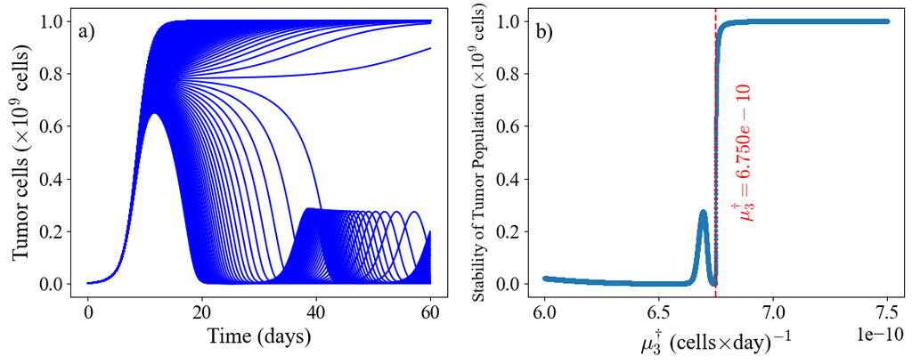

```python
import numpy as np
from scipy.integrate import odeint
import matplotlib.pyplot as plt

alpha1 = 0.69
K1 = 10**9
beta1 = 2.3e-10
mu1 = 1e-7

alpha2 = 1e-7
K2 = 10**9
kappa2 = 0.34

K3 = 2e7
alpha3 = 0.9
mu3_est = 1e-9
kappa3 = 0.35


def sis(TMC, t, alpha1, alpha2, alpha3, beta1, mu1, kappa2, mu3, kappa3, K1, K2, K3):
    T, M, C = TMC
    dT = alpha1 * T * (1 - (T / K1)) * (1 + (beta1 * M)) - mu1 * T * C
    dM = alpha2 * T * M * (1 - (M / K2)) - kappa2 * M
    dC = (alpha3 * T * C) / (K3 + T) - mu3 * C * T - kappa3 * C
    return [dT, dM, dC]


TMC0 = [2e6, 1e6, 5e5]

t_time = np.linspace(0, 60, 100000)
t_final = np.linspace(0, 60, 100000)

mu3_values_time = np.linspace(5e-10, 5e-9, 1000)

solutions_time = []
for mu3 in mu3_values_time:
    sol = odeint(
        sis, TMC0, t_time,
        args=(alpha1, alpha2, alpha3, beta1, mu1, kappa2, mu3, kappa3, K1, K2, K3)
    )
    solutions_time.append(sol)

mu3_values_final = np.linspace(6e-10, 7.5e-10, 20000)

final_T_values = []
for mu3 in mu3_values_final:
    sol = odeint(
        sis, TMC0, t_final,
        args=(alpha1, alpha2, alpha3, beta1, mu1, kappa2, mu3, kappa3, K1, K2, K3)
    )
    final_T_values.append(sol[-1, 0])

final_T_values = np.array(final_T_values)
mu3_values_final = np.array(mu3_values_final)

T_min = final_T_values.min()
T_max = final_T_values.max()
T_mid = 0.5 * (T_min + T_max)

a = b = None
for i in range(len(mu3_values_final) - 1):
    f_i = final_T_values[i] - T_mid
    f_ip1 = final_T_values[i + 1] - T_mid
    if f_i * f_ip1 < 0:
        a = mu3_values_final[i]
        b = mu3_values_final[i + 1]
        break


def final_T(mu3):
    sol = odeint(
        sis, TMC0, t_final,
        args=(alpha1, alpha2, alpha3, beta1, mu1, kappa2, mu3, kappa3, K1, K2, K3)
    )
    return sol[-1, 0]


mu3_star = None
if a is not None:
    for _ in range(100):
        m = 0.5 * (a + b)
        f_a = final_T(a) - T_mid
        f_m = final_T(m) - T_mid
        if f_a * f_m <= 0:
            b = m
        else:
            a = m
    mu3_star = 0.5 * (a + b)
    print(f"mu3* ≈ {mu3_star:.3e}")
else:
    print("No clear numerical crossing was found. Adjust the mu3 interval or the final time horizon.")

plt.rcParams.update({
    'font.size': 18,
    'xtick.labelsize': 18,
    'ytick.labelsize': 18,
    'font.family': 'serif',
    'font.serif': ['Times New Roman']
})

fig, axes = plt.subplots(1, 2, figsize=(12, 5))

for ax in axes:
    ax.yaxis.offsetText.set_visible(False)

for sol in solutions_time:
    axes[0].plot(t_time, sol[:, 0], '-', color='blue')

axes[0].set_xlabel('Time (days)', fontsize=20)
axes[0].set_ylabel(r'Tumor cells ($\times10^9$ cells)', fontsize=20)
axes[0].grid(False)
axes[0].text(0.02, 0.95, 'a)', transform=axes[0].transAxes, fontsize=20, va='top')

axes[1].plot(mu3_values_final, final_T_values, '-o', markersize=3, label='Final $T(t)$')
if mu3_star is not None:
    axes[1].axvline(x=mu3_star, color='r', linestyle='--')
    axes[1].text(
        mu3_star * 1.01,
        0.5 * (T_min + T_max),
        rf'$\mu_3^{{\dagger}}={mu3_star:.3e}$',
        rotation=90,
        verticalalignment='center',
        color='r',
        fontsize=18
    )

axes[1].set_xlabel(r'$\mu_3^{\dagger}$ (cells$\times$day)$^{-1}$', fontsize=20)
axes[1].set_ylabel(r'Stability of Tumor Population ($\times10^9$ cells)', fontsize=16)
axes[1].grid(False)
axes[1].text(0.02, 0.95, 'b)', transform=axes[1].transAxes, fontsize=20, va='top')

plt.tight_layout()
plt.savefig('./figures/fig10.pdf', bbox_inches='tight')
plt.show()
```

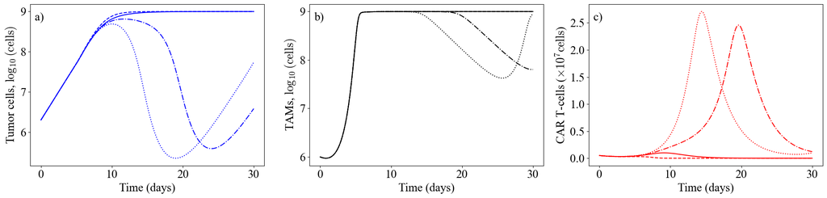

```python
import numpy as np
from scipy.integrate import solve_ivp
import matplotlib.pyplot as plt


def sis(t, TMC, alpha1, alpha2, alpha3, beta1, mu1, kappa2, mu3, kappa3, K1, K2, K3):
    T, M, C = TMC
    dT = alpha1 * T * (1 - (T / K1)) * (1 + (beta1 * M)) - mu1 * T * C
    dM = alpha2 * T * M * (1 - (M / K2)) - kappa2 * M
    dC = (alpha3 * T * C) / (K3 + T) - mu3 * C * T - kappa3 * C
    return [dT, dM, dC]


alpha1 = 0.69
K1 = 10**9
beta1 = 2.3 * 10**-10
mu1 = 10**-7

alpha2 = 10**-7
K2 = 10**9
kappa2 = 0.34

K3 = 2 * 10**7
alpha3 = 0.9
mu3 = 1e-9
kappa3 = 0.35

TMC0 = [2 * 10**6, 10**6, 5 * 10**5]

t_span = (0, 60)
t_eval = np.linspace(0, 30, 1000000)

mu3_values = [1e-9, 5e-9, 5e-10, 1e-11]
solutions = []

for mu3 in mu3_values:
    sol = solve_ivp(
        sis,
        t_span,
        TMC0,
        args=(alpha1, alpha2, alpha3, beta1, mu1, kappa2, mu3, kappa3, K1, K2, K3),
        t_eval=t_eval,
        method='LSODA'
    )
    solutions.append(sol)

plt.rcParams.update({
    'font.size': 16,
    'xtick.labelsize': 20,
    'ytick.labelsize': 20,
    'font.family': 'serif',
    'font.serif': ['Times New Roman']
})

fig, axes = plt.subplots(1, 3, figsize=(20, 5))

for ax in axes:
    ax.yaxis.offsetText.set_visible(False)

axes[0].plot(solutions[0].t, np.log10(solutions[0].y[0, :]), '-b', label=r'$\mu_3 = 6.751 \cdot 10^{-10}$')
axes[0].plot(solutions[1].t, np.log10(solutions[1].y[0, :]), '--b', label=r'$\mu_3 = 6.752 \cdot 10^{-10}$')
axes[0].plot(solutions[2].t, np.log10(solutions[2].y[0, :]), '-.b', label=r'$\mu_3 = 6.753 \cdot 10^{-10}$')
axes[0].plot(solutions[3].t, np.log10(solutions[3].y[0, :]), ':b', label=r'$\mu_3 = 6.754 \cdot 10^{-10}$')
axes[0].set_xlabel('Time (days)', fontsize=20)
axes[0].set_ylabel(r'Tumor cells, $\log_{10}(\text{cells})$', fontsize=20)
axes[0].text(0.02, 0.95, 'a)', transform=axes[0].transAxes, fontsize=20, va='top')

axes[1].plot(solutions[0].t, np.log10(solutions[0].y[1, :]), '-k', label=r'$\mu_3 = 6.751 \cdot 10^{-10}$')
axes[1].plot(solutions[1].t, np.log10(solutions[1].y[1, :]), '--k', label=r'$\mu_3 = 6.752 \cdot 10^{-10}$')
axes[1].plot(solutions[2].t, np.log10(solutions[2].y[1, :]), '-.k', label=r'$\mu_3 = 6.753 \cdot 10^{-10}$')
axes[1].plot(solutions[3].t, np.log10(solutions[3].y[1, :]), ':k', label=r'$\mu_3 = 6.754 \cdot 10^{-10}$')
axes[1].set_xlabel('Time (days)', fontsize=20)
axes[1].set_ylabel(r'TAMs, $\log_{10}(\text{cells})$', fontsize=20)
axes[1].text(0.02, 0.95, 'b)', transform=axes[1].transAxes, fontsize=20, va='top')

axes[2].plot(solutions[0].t, solutions[0].y[2, :], '-r', label=r'$\mu_3 = 6.751 \cdot 10^{-10}$')
axes[2].plot(solutions[1].t, solutions[1].y[2, :], '--r', label=r'$\mu_3 = 6.752 \cdot 10^{-10}$')
axes[2].plot(solutions[2].t, solutions[2].y[2, :], '-.r', label=r'$\mu_3 = 6.753 \cdot 10^{-10}$')
axes[2].plot(solutions[3].t, solutions[3].y[2, :], ':r', label=r'$\mu_3 = 6.754 \cdot 10^{-10}$')
axes[2].set_xlabel('Time (days)', fontsize=20)
axes[2].set_ylabel(r'CAR T-cells ($\times 10^{7} \text{cells}$)', fontsize=20)
axes[2].text(0.02, 0.95, 'c)', transform=axes[2].transAxes, fontsize=20, va='top')

plt.tight_layout()
plt.savefig('./figures/fig11.pdf', bbox_inches='tight')
plt.show()
```

# Scenario 2: increasing the dose of immunotherapy may improve tumor control

```
Total time with T(t) < 100.0 cells (C0 = 1e6): 0.00 days
Total time with T(t) < 100.0 cells (C0 = 1e7): 0.00 days
Total time with T(t) < 100.0 cells (C0 = 7e7): 12.40 days
Total time with T(t) < 100.0 cells (C0 = 9e7): 21.70 days
```

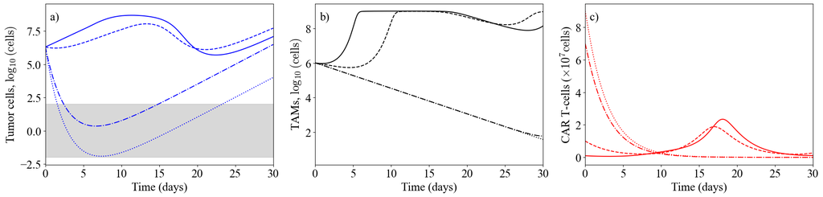

```python
import numpy as np
from scipy.integrate import odeint
import matplotlib.pyplot as plt


def sis(TMC, t, alpha1, alpha2, alpha3, beta1, mu1, kappa2, mu3, kappa3, K1, K2, K3):
    T, M, C = TMC
    dT = alpha1 * T * (1 - (T / K1)) * (1 + (beta1 * M)) - mu1 * T * C
    dM = alpha2 * T * M * (1 - (M / K2)) - kappa2 * M
    dC = (alpha3 * T * C) / (K3 + T) - mu3 * C * T - kappa3 * C
    return [dT, dM, dC]


alpha1 = 0.69
K1 = 10**9
beta1 = 2.3e-10
mu1 = 1e-7

alpha2 = 1e-7
K2 = 10**9
kappa2 = 0.34

K3 = 2e7
alpha3 = 0.9
mu3 = 6.752e-10
kappa3 = 0.35

t = np.linspace(0, 10000, 100000)
threshold = 1e2

TMC0 = [2 * 10**6, 10**6, 1e6]
sol1 = odeint(
    sis, TMC0, t,
    args=(alpha1, alpha2, alpha3, beta1, mu1, kappa2, mu3, kappa3, K1, K2, K3)
)
below_threshold_time = 0.0
for i in range(1, len(t)):
    if sol1[i, 0] < threshold:
        below_threshold_time += (t[i] - t[i - 1])
print(f"Total time with T(t) < {threshold} cells (C0 = 1e6): {below_threshold_time:.2f} days")

TMC0 = [2 * 10**6, 10**6, 1e7]
sol2 = odeint(
    sis, TMC0, t,
    args=(alpha1, alpha2, alpha3, beta1, mu1, kappa2, mu3, kappa3, K1, K2, K3)
)
below_threshold_time = 0.0
for i in range(1, len(t)):
    if sol2[i, 0] < threshold:
        below_threshold_time += (t[i] - t[i - 1])
print(f"Total time with T(t) < {threshold} cells (C0 = 1e7): {below_threshold_time:.2f} days")

TMC0 = [2 * 10**6, 10**6, 7e7]
sol3 = odeint(
    sis, TMC0, t,
    args=(alpha1, alpha2, alpha3, beta1, mu1, kappa2, mu3, kappa3, K1, K2, K3)
)
below_threshold_time = 0.0
for i in range(1, len(t)):
    if sol3[i, 0] < threshold:
        below_threshold_time += (t[i] - t[i - 1])
print(f"Total time with T(t) < {threshold} cells (C0 = 7e7): {below_threshold_time:.2f} days")

TMC0 = [2 * 10**6, 10**6, 9e7]
sol4 = odeint(
    sis, TMC0, t,
    args=(alpha1, alpha2, alpha3, beta1, mu1, kappa2, mu3, kappa3, K1, K2, K3)
)
below_threshold_time = 0.0
for i in range(1, len(t)):
    if sol4[i, 0] < threshold:
        below_threshold_time += (t[i] - t[i - 1])
print(f"Total time with T(t) < {threshold} cells (C0 = 9e7): {below_threshold_time:.2f} days")

aux = np.full_like(t, 1e2)

plt.rcParams.update({
    'font.size': 16,
    'xtick.labelsize': 20,
    'ytick.labelsize': 20,
    'font.family': 'serif',
    'font.serif': ['Times New Roman']
})

fig, axes = plt.subplots(1, 3, figsize=(20, 5))

for ax in axes:
    ax.yaxis.offsetText.set_visible(False)

axes[0].plot(t, np.log10(sol1[:, 0]), '-b', label=r'$C(0)=10^{6}$')
axes[0].plot(t, np.log10(sol2[:, 0]), '--b', label=r'$C(0)=10^{7}$')
axes[0].plot(t, np.log10(sol3[:, 0]), '-.b', label=r'$C(0)=7\cdot10^{7}$')
axes[0].plot(t, np.log10(sol4[:, 0]), ':b', label=r'$C(0)=9\cdot10^{7}$')
axes[0].fill_between(t, np.log10(10**-2), np.log10(aux), color='grey', alpha=0.3)
axes[0].set_xlim(0, 30)
axes[0].set_xlabel('Time (days)', fontsize=20)
axes[0].set_ylabel(r'Tumor cells, $\log_{10}(\text{cells})$', fontsize=20)
axes[0].text(0.02, 0.95, 'a)', transform=axes[0].transAxes, fontsize=20, va='top')

axes[1].plot(t, np.log10(sol1[:, 1]), '-k')
axes[1].plot(t, np.log10(sol2[:, 1]), '--k')
axes[1].plot(t, np.log10(sol3[:, 1]), '-.k')
axes[1].plot(t, np.log10(sol4[:, 1]), ':k')
axes[1].set_xlim(0, 30)
axes[1].set_xlabel('Time (days)', fontsize=20)
axes[1].set_ylabel(r'TAMs, $\log_{10}(\text{cells})$', fontsize=20)
axes[1].text(0.02, 0.95, 'b)', transform=axes[1].transAxes, fontsize=20, va='top')

axes[2].plot(t, sol1[:, 2], '-r', label=r'$C(0)=10^{6}$')
axes[2].plot(t, sol2[:, 2], '--r', label=r'$C(0)=10^{7}$')
axes[2].plot(t, sol3[:, 2], '-.r', label=r'$C(0)=7\cdot10^{7}$')
axes[2].plot(t, sol4[:, 2], ':r', label=r'$C(0)=9\cdot10^{7}$')
axes[2].set_xlim(0, 30)
axes[2].set_xlabel('Time (days)', fontsize=20)
axes[2].set_ylabel(r'CAR T-cells ($\times 10^{7} \text{cells}$)', fontsize=20)
axes[2].text(0.02, 0.95, 'c)', transform=axes[2].transAxes, fontsize=20, va='top')

plt.tight_layout()
plt.savefig('./figures/fig12.pdf', bbox_inches='tight')
plt.show()
```

# Scenario 3: evaluate the impact of TAM-associated factors such as $\beta_1$ on tumor growth in the context of CAR T-cell immunotherapy

```
===== Results for beta1 = 1.0e-07 =====
C(0) = 1.0e+06: total time with T(t) < 100.0 cells = 0.00 days
C(0) = 1.0e+07: total time with T(t) < 100.0 cells = 0.00 days
C(0) = 7.0e+07: total time with T(t) < 100.0 cells = 12.10 days
C(0) = 9.0e+07: total time with T(t) < 100.0 cells = 21.40 days

===== Results for beta1 = 2.0e-06 =====
C(0) = 1.0e+06: total time with T(t) < 100.0 cells = 0.00 days
C(0) = 1.0e+07: total time with T(t) < 100.0 cells = 0.00 days
C(0) = 7.0e+07: total time with T(t) < 100.0 cells = 2.10 days
C(0) = 9.0e+07: total time with T(t) < 100.0 cells = 15.20 days
```

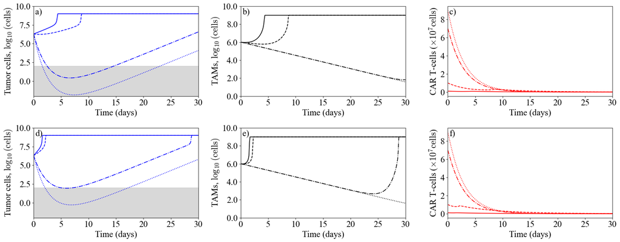

```python
import numpy as np
from scipy.integrate import odeint
import matplotlib.pyplot as plt
import matplotlib.ticker as mticker


def sis(TMC, t, alpha1, alpha2, alpha3, beta1, mu1, kappa2, mu3, kappa3, K1, K2, K3):
    T, M, C = TMC
    dT = alpha1 * T * (1 - (T / K1)) * (1 + (beta1 * M)) - mu1 * T * C
    dM = alpha2 * T * M * (1 - (M / K2)) - kappa2 * M
    dC = (alpha3 * T * C) / (K3 + T) - mu3 * C * T - kappa3 * C
    return [dT, dM, dC]


alpha1 = 0.69
K1 = 10**9
mu1 = 1e-7

alpha2 = 1e-7
K2 = 10**9
kappa2 = 0.34

K3 = 2e7
alpha3 = 0.9
mu3 = 6.752e-10
kappa3 = 0.35

t = np.linspace(0, 10000, 100000)
threshold = 1e2
C0_values = [1e6, 1e7, 7e7, 9e7]
beta_values = [1e-7, 2e-6]

sols_T = []
sols_M = []
sols_C = []

for beta1 in beta_values:
    row_T = []
    row_M = []
    row_C = []
    print(f"\n===== Results for beta1 = {beta1:.1e} =====")

    for C0 in C0_values:
        TMC0 = [2 * 10**6, 10**6, C0]
        sol = odeint(
            sis,
            TMC0,
            t,
            args=(alpha1, alpha2, alpha3, beta1, mu1, kappa2, mu3, kappa3, K1, K2, K3)
        )

        below_threshold_time = 0.0
        for i in range(1, len(t)):
            if sol[i, 0] < threshold:
                below_threshold_time += (t[i] - t[i - 1])

        print(
            f"C(0) = {C0:.1e}: total time with T(t) < {threshold} cells = "
            f"{below_threshold_time:.2f} days"
        )

        row_T.append(sol[:, 0])
        row_M.append(sol[:, 1])
        row_C.append(sol[:, 2])

    sols_T.append(row_T)
    sols_M.append(row_M)
    sols_C.append(row_C)

aux = np.full_like(t, threshold)

plt.rcParams.update({
    'font.size': 16,
    'xtick.labelsize': 20,
    'ytick.labelsize': 20,
    'font.family': 'serif',
    'font.serif': ['Times New Roman']
})

fig, axes = plt.subplots(2, 3, figsize=(20, 8))

for ax in axes.flatten():
    ax.yaxis.offsetText.set_visible(False)

line_styles = ['-', '--', '-.', ':']
labels_C0 = [
    r'$C(0)=10^{6}$',
    r'$C(0)=10^{7}$',
    r'$C(0)=7\cdot10^{7}$',
    r'$C(0)=9\cdot10^{7}$'
]

row = 0

for j in range(4):
    axes[0, 0].plot(t, np.log10(sols_T[row][j]), line_styles[j], color='b', label=labels_C0[j])
axes[0, 0].fill_between(t, np.log10(10**-2), np.log10(aux), color='grey', alpha=0.3)
axes[0, 0].set_xlim(0, 30)
axes[0, 0].set_ylim(-2, 10)
axes[0, 0].set_xlabel('Time (days)', fontsize=20)
axes[0, 0].set_ylabel(r'Tumor cells, $\log_{10}(\text{cells})$', fontsize=20)
axes[0, 0].text(0.01, 0.98, 'a)', transform=axes[0, 0].transAxes, fontsize=20, va='top')

for j in range(4):
    axes[0, 1].plot(t, np.log10(sols_M[row][j]), line_styles[j], color='k')
axes[0, 1].set_xlim(0, 30)
axes[0, 1].set_ylim(0, 10)
axes[0, 1].set_xlabel('Time (days)', fontsize=20)
axes[0, 1].set_ylabel(r'TAMs, $\log_{10}(\text{cells})$', fontsize=20)
axes[0, 1].yaxis.set_major_formatter(mticker.FormatStrFormatter('%.1f'))
axes[0, 1].text(0.01, 0.98, 'b)', transform=axes[0, 1].transAxes, fontsize=20, va='top')

for j in range(4):
    axes[0, 2].plot(t, sols_C[row][j], line_styles[j], color='r')
axes[0, 2].set_xlim(0, 30)
axes[0, 2].set_xlabel('Time (days)', fontsize=20)
axes[0, 2].set_ylabel(r'CAR T-cells ($\times 10^{7} \text{cells}$)', fontsize=20)
axes[0, 2].text(0.01, 0.98, 'c)', transform=axes[0, 2].transAxes, fontsize=20, va='top')

row = 1

for j in range(4):
    axes[1, 0].plot(t, np.log10(sols_T[row][j]), line_styles[j], color='b')
axes[1, 0].fill_between(t, np.log10(10**-2), np.log10(aux), color='grey', alpha=0.3)
axes[1, 0].set_xlim(0, 30)
axes[1, 0].set_ylim(-2, 10)
axes[1, 0].set_xlabel('Time (days)', fontsize=20)
axes[1, 0].set_ylabel(r'Tumor cells, $\log_{10}(\text{cells})$', fontsize=20)
axes[1, 0].text(0.01, 0.98, 'd)', transform=axes[1, 0].transAxes, fontsize=20, va='top')

for j in range(4):
    axes[1, 1].plot(t, np.log10(sols_M[row][j]), line_styles[j], color='k')
axes[1, 1].set_xlim(0, 30)
axes[1, 1].set_ylim(0, 10)
axes[1, 1].set_xlabel('Time (days)', fontsize=20)
axes[1, 1].set_ylabel(r'TAMs, $\log_{10}(\text{cells})$', fontsize=20)
axes[1, 1].yaxis.set_major_formatter(mticker.FormatStrFormatter('%.1f'))
axes[1, 1].text(0.01, 0.98, 'e)', transform=axes[1, 1].transAxes, fontsize=20, va='top')

for j in range(4):
    axes[1, 2].plot(t, sols_C[row][j], line_styles[j], color='r')
axes[1, 2].set_xlim(0, 30)
axes[1, 2].set_xlabel('Time (days)', fontsize=20)
axes[1, 2].set_ylabel(r'CAR T-cells ($\times 10^{7} \text{cells}$)', fontsize=20)
axes[1, 2].text(0.01, 0.98, 'f)', transform=axes[1, 2].transAxes, fontsize=20, va='top')

plt.tight_layout()
plt.savefig('./figures/fig13.pdf', bbox_inches='tight')
plt.show()
```